# Today’s Files

### Exercise

1. Create a boxplot looking at continents by percent of medals coming from summer sports. What can you gather from this plot?
2. Unscramble the statements to find the 3 countries with the highest percentage of medals coming from winter sports.

**Click here for the answers**

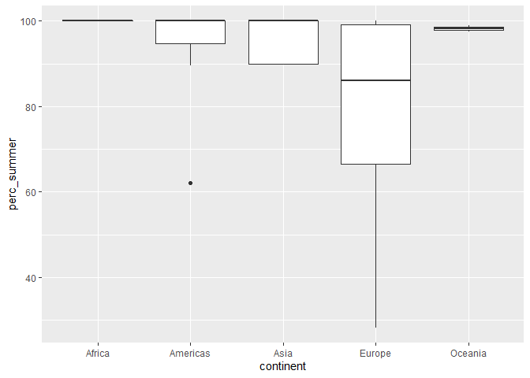

```r
ggplot(olympics, aes(continent, perc_summer)) + geom_boxplot()
```

```r
# olympics %>%
#
#   head(3)
#
#   arrange(desc(perc_winter)) %>%
#
#   mutate(perc_winter = 100 - perc_summer) %>%
#
#   select(country, continent, perc_winter) %>%
#

olympics %>%
  mutate(perc_winter = 100-perc_summer) %>%
  arrange(desc(perc_winter)) %>%
  select(country, continent, perc_winter) %>%
  head(3)
```

```
## # A tibble: 3 x 3
##   country  continent perc_winter
##   <chr>    <chr>           <dbl>
## 1 Austria  Europe           71.7
## 2 Norway   Europe           69.0
## 3 Slovenia Europe           44.1
```

## Scatter

The final type of plot that we are going to look is one that compares multiple continuous variables. The scatter plot is a good choice for investigating the relationship between two continuous variables and it allows you to look for missing values that are denoted as such and to find other unusual values. geom_point() is the function to create scatter plots

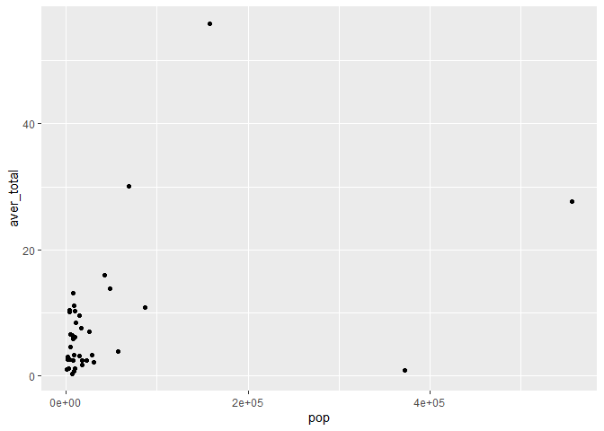

```r
# Initial Plot looking at population and average number of medals
ggplot(olympics, aes(pop, aver_total)) + geom_point()
```

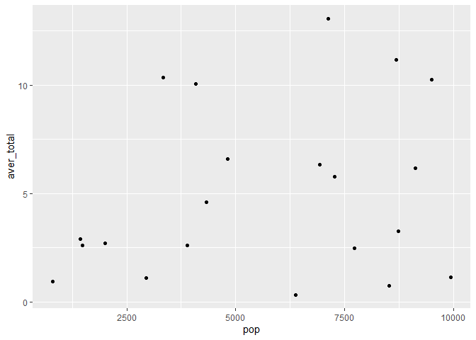

```r
# A few outliers at higher populations, let's focus in on the smaller populations
olympics %>%
  filter(pop < 10000) %>%
  ggplot(aes(pop, aver_total)) + geom_point()
```

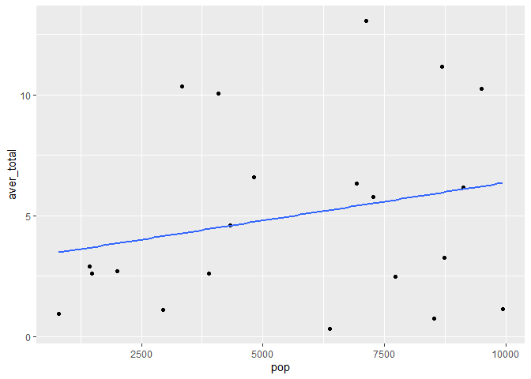

```r
olympics %>%
  filter(pop < 10000) %>%
  ggplot(aes(pop, aver_total)) + geom_point() + geom_smooth(method="lm", se = FALSE)
```

Next week we will work on creating better visualizations.